# PA1_template

Carlos Ortega

November 8, 2018

```r
# Loading Data
library(ggplot2)
library(plyr)
library(lattice)
```

## Importing Data

Reading data from activity.csv

```r
activity <- read.csv("activity.csv")
str(activity)
```

```
## 'data.frame':    17568 obs. of  3 variables:
##  $ steps   : int  NA NA NA NA NA NA NA NA NA NA ...
##  $ date    : Factor w/ 61 levels "2012-10-01","2012-10-02",..: 1 1 1 1 1 1 1 1 1 1 ...
##  $ interval: int  0 5 10 15 20 25 30 35 40 45 ...
```

```r
summary(activity)
```

```
##      steps                date          interval
##  Min.   :  0.00   2012-10-01:  288   Min.   :   0.0
##  1st Qu.:  0.00   2012-10-02:  288   1st Qu.: 588.8
##  Median :  0.00   2012-10-03:  288   Median :1177.5
##  Mean   : 37.38   2012-10-04:  288   Mean   :1177.5
##  3rd Qu.: 12.00   2012-10-05:  288   3rd Qu.:1766.2
##  Max.   :806.00   2012-10-06:  288   Max.   :2355.0
##  NA's   :2304     (Other)   :15840
```

# Processing the Data

Ordering the data by date and taking away the NA values

```r
activity$day <- weekdays(as.Date(activity$date))
activity$DateTime <- as.POSIXct(activity$date, format="%Y-%m-%d")
clean <- activity[!is.na(activity$steps),]
summary(clean)
```

```
##      steps                date          interval          day
##  Min.   :  0.00   2012-10-02:  288   Min.   :   0.0   Length:15264
##  1st Qu.:  0.00   2012-10-03:  288   1st Qu.: 588.8   Class :character
##  Median :  0.00   2012-10-04:  288   Median :1177.5   Mode  :character
##  Mean   : 37.38   2012-10-05:  288   Mean   :1177.5
##  3rd Qu.: 12.00   2012-10-06:  288   3rd Qu.:1766.2
##  Max.   :806.00   2012-10-07:  288   Max.   :2355.0
##                   (Other)   :13536
##     DateTime
##  Min.   :2012-10-02 00:00:00
##  1st Qu.:2012-10-16 00:00:00
##  Median :2012-10-29 00:00:00
##  Mean   :2012-10-30 16:43:01
##  3rd Qu.:2012-11-16 00:00:00
##  Max.   :2012-11-29 00:00:00
##
```

#### 1. Calculate the total number of steps taken per day (ignore the missing values)

```r
table <- aggregate(activity$steps ~ activity$date, FUN=sum)
colnames(table) <- c("Date", "Steps")
```

View total number of steps taken per day as a Histogram

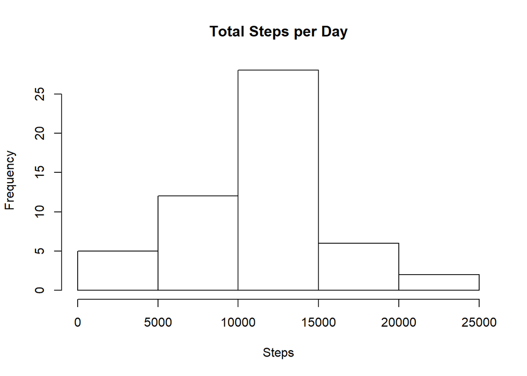

```r
hist(table$Steps, breaks = 5, xlab = "Steps", main = "Total Steps per Day")
```

```r
mean_steps <- as.integer(mean(table$Steps))
median_steps <- as.integer(median(table$Steps))
```

Mean and median of the total number of steps taken per day are 10766 steps and 10765 steps, respectively.

## What is the average daily activity pattern?

#### 1. Make a time series plot (i.e. type = “l”) of the 5-minute interval (x-axis) and the average number of steps taken, averaged across all days (y-axis)

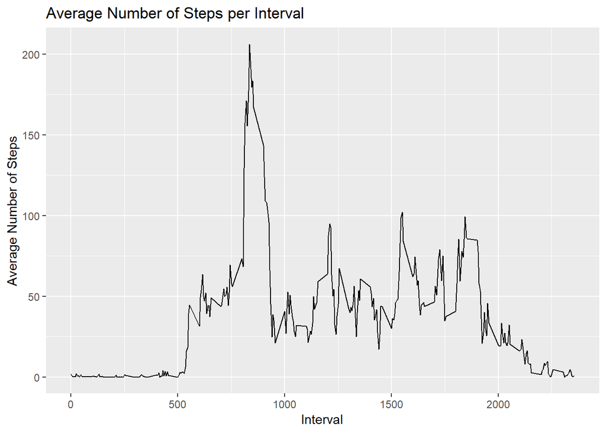

```r
table <- ddply(clean, .(interval), summarize, Avg=mean(steps))

#we create a line plot with the number of steps per interval
p <- ggplot(table, aes(x=interval, y=Avg), xlab="Interval", ylab="Average Number of Steps")
p + geom_line()+xlab("Interval")+ylab("Average Number of Steps")+ggtitle("Average Number of Steps per Interval")
```

```r
#maximum steps by interval
max <- as.integer(max(table$Avg))

#maximum average number of steps
max_val <- table[table$Avg == max, 1]
```

The maximum number of steps for a 5-minute interval was 206 steps.

## Imputing missing values

#### Calculate and report the total number of missing values in the dataset (i.e. the total number of rows with NAs)

```r
#number of NAs in the original data set
total_nas <- nrow(activity) - nrow(clean)
```

The total number of NAs is 2304

[figure not shown]

```r
#Create the average number of steps per weekday and interval
table <- ddply(clean, .(interval, day), summarize, Avg=mean(steps))

#Dataset with all NAs
nadata <- activity[is.na(activity$steps),]

#merge na data with average weekday interval for substitution
newdata <- merge(nadata, table, by=c("interval", "day"))

#reorder the data in order to have the same format as the clean data
newdataTwo <- newdata[,c(6,4,1,2,5)]
colnames(newdataTwo) <- c("steps", "date", "interval", "day", "DateTime")

#merge the NA data (newdata) + non NA data (clean)
mergeVar <- rbind(clean, newdataTwo)

#Create sum of steps per date to compare with step 1
sumTable <- aggregate(mergeVar$steps ~ mergeVar$date, FUN=sum)
tableSum <- aggregate(activity$steps ~ activity$date, FUN=sum)
colnames(sumTable) <- c("Date", "Steps")

# mean
mean_missing <- as.integer(mean(sumTable$Steps))

#median
median_missing <- as.integer(median(sumTable$Steps))

#Create the histogram displaying the total steps per day

hist(sumTable$Steps, breaks = 5, xlab = "Steps", main = "Total Steps per Day with NAs Fixed", col = "Black")

legend("topright", c("Imputed Data", "Non-NA Data"), fill = c("black", "grey"))
```

```r
mean_diff <- mean_missing - mean_steps
median_diff <- median_missing - median_steps
```

The new mean of the imputed data is 10821 steps compared to the old mean of 10766 steps. That creates a difference of 55 steps on average per day.

The new median of the imputed data is 11015 steps compared to the old median of 10765 steps. That creates a difference of 250 steps for the median.

## Activity Patterns Between Weekdays and Weekends

#### Create a new factor variable in the dataset with two levels - “weekday” and “weekend” indicating whether a given date is a weekday or weekend day.

#### Make a panel plot containing a time series plot (i.e. type = “l”) of the 5-minute interval (x-axis) and the average number of steps taken, averaged across all weekday days or weekend days (y-axis).

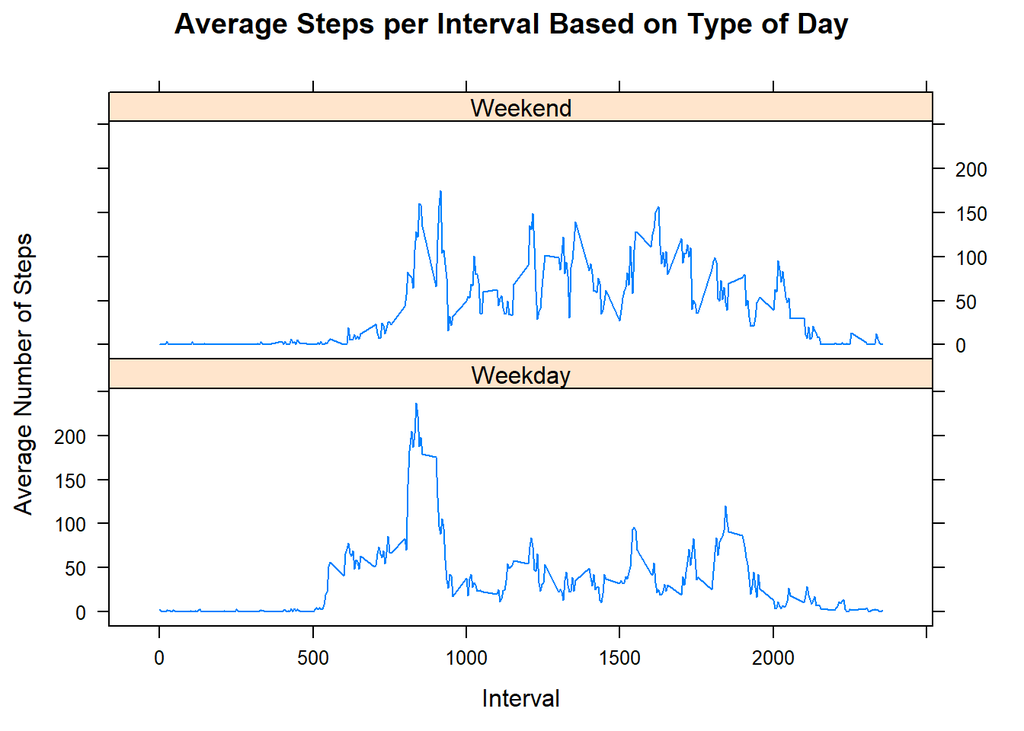

```r
mergeVar$DayCategory <- ifelse(mergeVar$day %in% c("Saturday", "Sunday"), "Weekend", "Weekday")

#summarize data by interval and type o the day
interval <- ddply(mergeVar, .(interval, DayCategory), summarize, Avg=mean(steps))

#Plot
xyplot(Avg~interval|DayCategory, data=interval, type="l", layout = c(1,2),
       main="Average Steps per Interval Based on Type of Day",
       ylab="Average Number of Steps", xlab="Interval")
```